# Kaggle House Price Notes

> *Everything I leraned from Kaggle competition **House Prices: Advanced Regression Techniques**.*

Description of the data set: http://ww2.amstat.org/publications/jse/v19n3/Decock/DataDocumentation.txt

##### Outline

- Inputing missing values
- Transforming categorical variables
- Label encoding ordinal variables
- Box Cox transformation of skewed features (instead of log-transformation)
- Dummy variables for categorical features

#### Overview

```python
# setup
import numpy as np
import pandas as pd
import matplotlib.pyplot as plt
import seaborn as sns
%matplotlib inline

# limiting floats output to three decimals
pd.set_option('display.float_format', lambda x: '{:.3f}'.format(x))

# set figure style
color = sns.color_palette()
sns.set_style('darkgrid')

# ignore warnings
import warnings
def ignore_warn(*args, **kwargs): pass
warnings.warn = ignore_warn

# acquire data sets
train = pd.read_csv('../input/house_price/train.csv')
test = pd.read_csv('../input/house_price/test.csv')
```

```python
train.head()
```

|  | Id | MSSubClass | MSZoning | LotFrontage | LotArea | Street | Alley | LotShape | LandContour | Utilities | ... | PoolArea | PoolQC | Fence | MiscFeature | MiscVal | MoSold | YrSold | SaleType | SaleCondition | SalePrice |
| --- | --- | --- | --- | --- | --- | --- | --- | --- | --- | --- | --- | --- | --- | --- | --- | --- | --- | --- | --- | --- | --- |
| 0 | 1 | 60 | RL | 65.000 | 8450 | Pave | NaN | Reg | Lvl | AllPub | ... | 0 | NaN | NaN | NaN | 0 | 2 | 2008 | WD | Normal | 208500 |
| 1 | 2 | 20 | RL | 80.000 | 9600 | Pave | NaN | Reg | Lvl | AllPub | ... | 0 | NaN | NaN | NaN | 0 | 5 | 2007 | WD | Normal | 181500 |
| 2 | 3 | 60 | RL | 68.000 | 11250 | Pave | NaN | IR1 | Lvl | AllPub | ... | 0 | NaN | NaN | NaN | 0 | 9 | 2008 | WD | Normal | 223500 |
| 3 | 4 | 70 | RL | 60.000 | 9550 | Pave | NaN | IR1 | Lvl | AllPub | ... | 0 | NaN | NaN | NaN | 0 | 2 | 2006 | WD | Abnorml | 140000 |
| 4 | 5 | 60 | RL | 84.000 | 14260 | Pave | NaN | IR1 | Lvl | AllPub | ... | 0 | NaN | NaN | NaN | 0 | 12 | 2008 | WD | Normal | 250000 |

5 rows × 81 columns

```python
test.head()
```

|  | Id | MSSubClass | MSZoning | LotFrontage | LotArea | Street | Alley | LotShape | LandContour | Utilities | ... | ScreenPorch | PoolArea | PoolQC | Fence | MiscFeature | MiscVal | MoSold | YrSold | SaleType | SaleCondition |
| --- | --- | --- | --- | --- | --- | --- | --- | --- | --- | --- | --- | --- | --- | --- | --- | --- | --- | --- | --- | --- | --- |
| 0 | 1461 | 20 | RH | 80.000 | 11622 | Pave | NaN | Reg | Lvl | AllPub | ... | 120 | 0 | NaN | MnPrv | NaN | 0 | 6 | 2010 | WD | Normal |
| 1 | 1462 | 20 | RL | 81.000 | 14267 | Pave | NaN | IR1 | Lvl | AllPub | ... | 0 | 0 | NaN | NaN | Gar2 | 12500 | 6 | 2010 | WD | Normal |
| 2 | 1463 | 60 | RL | 74.000 | 13830 | Pave | NaN | IR1 | Lvl | AllPub | ... | 0 | 0 | NaN | MnPrv | NaN | 0 | 3 | 2010 | WD | Normal |
| 3 | 1464 | 60 | RL | 78.000 | 9978 | Pave | NaN | IR1 | Lvl | AllPub | ... | 0 | 0 | NaN | NaN | NaN | 0 | 6 | 2010 | WD | Normal |
| 4 | 1465 | 120 | RL | 43.000 | 5005 | Pave | NaN | IR1 | HLS | AllPub | ... | 144 | 0 | NaN | NaN | NaN | 0 | 1 | 2010 | WD | Normal |

5 rows × 80 columns

###### Observations

1. Both sets contain 80 features; we want to predict `SalePrice` for the test data set.
2. The `Id` column is unnecessary and we should drop it.

```python
# List out all the features

train.columns.values
```

[output not shown]

```python
# Drop the Id column

print("Before: ", train.shape, test.shape)
train.drop('Id', axis=1, inplace=True)
test.drop('Id', axis=1, inplace=True)
print("After: ", train.shape, test.shape)
```

```
Before:  (1460, 81) (1459, 80)
After:  (1460, 80) (1459, 79)
```

#### Outliers

From the `SPECIAL NOTES` paragraph of the data set description (see link on the top), there exist some outliers we wish to identify. The description explicitly says "two of them are simply unusual sales ... I would recommend removing any houses with more than 4000 square feet from the data set (which eliminates these 5 unusual observations)". Thus, it makes sense for us to plot a graph of `GrLivArea` (which stands for "above ground living area square feet") against `SalePrice`.

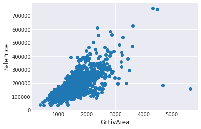

```python
fig, ax = plt.subplots()
ax.scatter(x=train['GrLivArea'], y=train['SalePrice'])
plt.ylabel('SalePrice', fontsize=12)
plt.xlabel('GrLivArea', fontsize=12)
plt.show()
```

`plt.subplots(nrows=1, ncols=1, ...)` : create a figure and a set of subplots.

- This utility wrapper makes it convenient to create common layouts of subplots, including the enclosing figure object, in a single call.
- *Parameters*
  - nrows, ncols: int, optional, default=1
- *Returns*
  - `fig` : an object of class `matplotlib.figure.Figure`
  - `ax` : axes object or array of Axes objects.
  - It can be either a single object of class `matplotlib.axes.Axes` or an array of Axes of objecddts if more than one subplot was created.
- *Usage*
  1. Create two sets of data, `x` and `y`.
  2. Initialize the plot with `fig, ax = plt.subplots()`.
  3. Plot the data with `ax.<plot>(x, y)`.
  4. Title, legends, etc.

###### Observations

There are two obvious outliers on the bottom right corner; we want to remove them from the data set.

```python
outliers = train[(train['GrLivArea'] > 4000) & (train['SalePrice']<300000)]
train.drop(outliers.index, inplace=True)
```

`train.drop(labels=None, inplace=False)` : Return new object with labels in requested axis removed.

- `labels`: single label or list-like Index or Column labels to drop.
- Here we passed outliers.index as two "single labels" and they get dropped.

Plotting again, we see the two ouliers on the bottom right cornor are removed. As a remark, be very careful when removing outliers as this operations may affect the overall performance of our model later on.

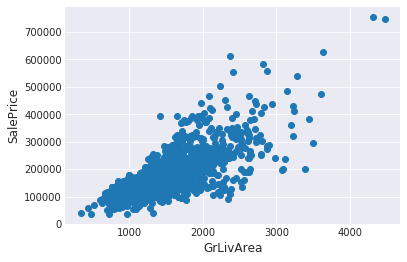

```python
fig, ax = plt.subplots()
ax.scatter(x=train['GrLivArea'], y=train['SalePrice'])
plt.ylabel('SalePrice', fontsize=12)
plt.xlabel('GrLivArea', fontsize=12)
plt.show()
```

#### Analyze Target Variable

We want to see the distribution of our target variable, `SalePrice`.

```python
from scipy import stats
from scipy.stats import norm
```

The module `scipy.stats` contains a large number of probability distributions as well as a library of statistical functions. As a remark, there are two generic random variable classes `rv_discrete` and `rv_continuous`.

`norm` is a normal continuous random variable; the location `loc` keyword specifies the mean; the scale `scale` keyword specifies the standard deviation. As an instance of the `rv_continuous` class, `norm` object inherits from it a collection of generic methods, e.g. `mean`, `var`, `fit`, etc.

```
 mu = 180932.92 and sigma = 79467.79
```

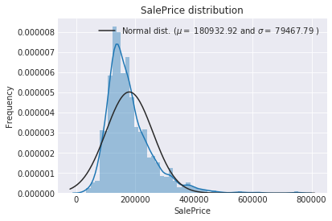

```python
sns.distplot(train['SalePrice'], fit=norm);

plt.legend(['Normal dist. ($\mu=$ {:.2f} and $\sigma=$ {:.2f} )'.format(mu, sigma)],
            loc='best')
plt.ylabel('Frequency')
plt.title('SalePrice distribution')

(mu, sigma) = norm.fit(train['SalePrice'])
print( '\n mu = {:.2f} and sigma = {:.2f}\n'.format(mu, sigma))
```

`sns.distplot(a, fit=None)`

- Flexibly plot a univariate distribution of observations.
- `fit=norm` : plot a maximum likelihood gaussian distribution fit (black in the figure above)

[figure not shown]

```python
fig = plt.figure()
res = stats.probplot(train['SalePrice'], fit=False, plot=plt)
plt.show()
```

`plt.figure()` : Creates a new figure

`stats.probplot(x, plot=None)`

- calculate quantiles for a probability plot
- generates a probability plot of sample data against the quantiles of a specified theoretical distribution (default to be the normal distribution).
- `probplot` optionally calculates a best-fit line for the data and plots the results using Matplotlib or a given plot function (the red line above).
- `plot=plt` : generate the plot

###### Observation:

The target variable is right skewed. As linear models love normally distributed data, we want to transform this variable (using log transformation) and make it more normally distributed.

*Remark.* The log transformation can be used to make highly skewed distributions less skewed thus help make patterns in the data more interpretable and meet the assumptions of inferential statistics.

[output not shown]

[figure not shown]

[figure not shown]

```python
train['SalePrice'] = np.log1p(train['SalePrice']) # apply np.log1p to every single entry

(mu, sigma) = norm.fit(train['SalePrice'])
print( '\n mu = {:.2f} and sigma = {:.2f}\n'.format(mu, sigma))

plt.legend(['Normal dist. ($\mu=$ {:.2f} and $\sigma=$ {:.2f} )'.format(mu, sigma)],
            loc='best')
plt.ylabel('Frequency')
plt.title('SalePrice distribution')

sns.distplot(train['SalePrice'], fit=norm);

fig = plt.figure()
res = stats.probplot(train['SalePrice'], plot=plt)
plt.show()
```

`np.log1p` : calculate log(1+x), element-wise.

###### Observation

The skewness is significantly reduced and the normal distribution line fits much better. We are read to deal with individual features.

#### Correlation of Features

We want to see the correlation between each pair of features.

```
<function seaborn.matrix.heatmap(data, vmin=None, vmax=None, cmap=None, center=None, robust=False, annot=None, fmt='.2g', annot_kws=None, linewidths=0, linecolor='white', cbar=True, cbar_kws=None, cbar_ax=None, square=False, xticklabels='auto', yticklabels='auto', mask=None, ax=None, **kwargs)>
```

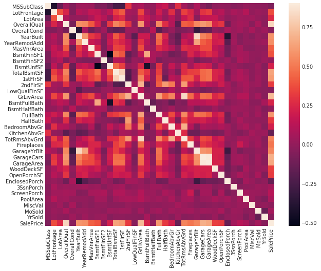

```python
corrmat = train.corr()
plt.subplots(figsize=(10, 8))
sns.heatmap(corrmat, vmax=0.9, square=False)
sns.heatmap
```

`train,corr()` : compute pairwise correlation of columns, excluding NA/null values.

`sns.heatmap(data, vmax=None, square=False)` : plot rectangular data as a color-encoded matrix.

#### Identifying Missing Data

We want to combine both training and test data into one single DataFrame. Note that, since test data does not have `SalePrice` column, we shall drop this column from the combined DataFrame.

```python
ntrain = train.shape[0]
ntest= test.shape[0]
y_train = train.SalePrice.values

combine = pd.concat((train, test)).reset_index(drop=True)
combine.drop(['SalePrice'], axis=1, inplace=True)

print(combine.shape)
combine.head()
```

```
(2917, 79)
```

|  | 1stFlrSF | 2ndFlrSF | 3SsnPorch | Alley | BedroomAbvGr | BldgType | BsmtCond | BsmtExposure | BsmtFinSF1 | BsmtFinSF2 | ... | SaleType | ScreenPorch | Street | TotRmsAbvGrd | TotalBsmtSF | Utilities | WoodDeckSF | YearBuilt | YearRemodAdd | YrSold |
| --- | --- | --- | --- | --- | --- | --- | --- | --- | --- | --- | --- | --- | --- | --- | --- | --- | --- | --- | --- | --- | --- |
| 0 | 856 | 854 | 0 | NaN | 3 | 1Fam | TA | No | 706.000 | 0.000 | ... | WD | 0 | Pave | 8 | 856.000 | AllPub | 0 | 2003 | 2003 | 2008 |
| 1 | 1262 | 0 | 0 | NaN | 3 | 1Fam | TA | Gd | 978.000 | 0.000 | ... | WD | 0 | Pave | 6 | 1262.000 | AllPub | 298 | 1976 | 1976 | 2007 |
| 2 | 920 | 866 | 0 | NaN | 3 | 1Fam | TA | Mn | 486.000 | 0.000 | ... | WD | 0 | Pave | 6 | 920.000 | AllPub | 0 | 2001 | 2002 | 2008 |
| 3 | 961 | 756 | 0 | NaN | 3 | 1Fam | Gd | No | 216.000 | 0.000 | ... | WD | 0 | Pave | 7 | 756.000 | AllPub | 0 | 1915 | 1970 | 2006 |
| 4 | 1145 | 1053 | 0 | NaN | 4 | 1Fam | TA | Av | 655.000 | 0.000 | ... | WD | 0 | Pave | 9 | 1145.000 | AllPub | 192 | 2000 | 2000 | 2008 |

5 rows × 79 columns

`pd.concat` : concatenate pandas objects along a particular axis with optional set logic along the other axes.

`pd.DataFrame.reset_index(drop=True)` : for DataFarme with multi-level index, return new DataFrame with labeling information in the columns under index names. If `drop=True`, we would not insert index into dataframe columns. This resets the index to the default integer index.

- In other words, Doing `drop=False` would creating a new index column.

```python
missing_perc = (combine.isnull().sum() / len(combine)) * 100
# missing_val: a Series containing percentage of missing value of each feature

# Now we drop the rows with no missing values, i.e. (missing_val[missing_val==0])
# sort and display the first 15 columns
missing_perc = missing_perc.drop(missing_perc[missing_perc == 0].index).sort_values(ascending=False)

# Put this into a DataFrame
missing_data = pd.DataFrame({'Missing Ratio' : missing_perc})
missing_data.head(20)
```

|  | Missing Ratio |
| --- | --- |
| PoolQC | 99.691 |
| MiscFeature | 96.400 |
| Alley | 93.212 |
| Fence | 80.425 |
| FireplaceQu | 48.680 |
| LotFrontage | 16.661 |
| GarageQual | 5.451 |
| GarageCond | 5.451 |
| GarageFinish | 5.451 |
| GarageYrBlt | 5.451 |
| GarageType | 5.382 |
| BsmtExposure | 2.811 |
| BsmtCond | 2.811 |
| BsmtQual | 2.777 |
| BsmtFinType2 | 2.743 |
| BsmtFinType1 | 2.708 |
| MasVnrType | 0.823 |
| MasVnrArea | 0.788 |
| MSZoning | 0.137 |
| BsmtFullBath | 0.069 |

Time to see the percentages of missing values:

```
Text(0.5,1,'Percent missing data by feature')
```

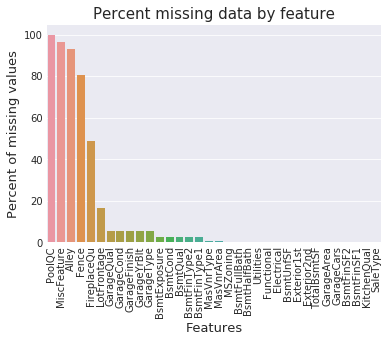

```python
f, ax = plt.subplots(figsize=(6, 4))
plt.xticks(rotation='90') # rotation of text on the x-axis

sns.barplot(x=missing_perc.index, y=missing_perc) # x: features, y: missing percentage
plt.xlabel('Features', fontsize=13)
plt.ylabel('Percent of missing values', fontsize=13)
plt.title('Percent missing data by feature', fontsize=15)
```

#### Imputing Missing Values

```python
# Pool: NA means No Pool, thus we fill with None.
combine['PoolQC'].fillna('None', inplace=True)

# Similar for MiscFeature, Alley, Fence, FireplaceQu
combine['MiscFeature'] = combine['MiscFeature'].fillna('None')
combine["Alley"] = combine["Alley"].fillna("None")
combine["Fence"] = combine["Fence"].fillna("None")
combine["FireplaceQu"] = combine["FireplaceQu"].fillna("None")

# We process the rest according to the documentation
# Some of them are filled with None (like above)
# Some of the nulls means 0 (for example, GarageArea)
# Some of the nulls we want to fill with the mode or median
# Otherws might have special default values
# Read data description for the details

combine["LotFrontage"] = combine.groupby("Neighborhood")["LotFrontage"].transform(
    lambda x: x.fillna(x.median()))

for col in ('GarageType', 'GarageFinish', 'GarageQual', 'GarageCond'):
    combine[col] = combine[col].fillna('None')

for col in ('GarageYrBlt', 'GarageArea', 'GarageCars'):
    combine[col] = combine[col].fillna(0)

for col in ('BsmtFinSF1', 'BsmtFinSF2', 'BsmtUnfSF','TotalBsmtSF', 'BsmtFullBath', 'BsmtHalfBath'):
    combine[col] = combine[col].fillna(0)

for col in ('BsmtQual', 'BsmtCond', 'BsmtExposure', 'BsmtFinType1', 'BsmtFinType2'):
    combine[col] = combine[col].fillna('None')


combine["MasVnrType"] = combine["MasVnrType"].fillna("None")
combine["MasVnrArea"] = combine["MasVnrArea"].fillna(0)

combine['MSZoning'] = combine['MSZoning'].fillna(combine['MSZoning'].mode()[0])

combine = combine.drop(['Utilities'], axis=1)

combine["Functional"] = combine["Functional"].fillna("Typ")

combine['Electrical'] = combine['Electrical'].fillna(combine['Electrical'].mode()[0])
combine['KitchenQual'] = combine['KitchenQual'].fillna(combine['KitchenQual'].mode()[0])
combine['Exterior1st'] = combine['Exterior1st'].fillna(combine['Exterior1st'].mode()[0])
combine['Exterior2nd'] = combine['Exterior2nd'].fillna(combine['Exterior2nd'].mode()[0])

combine['SaleType'] = combine['SaleType'].fillna(combine['SaleType'].mode()[0])
combine['MSSubClass'] = combine['MSSubClass'].fillna("None")
```

```python
# Any missing value left?

missing_perc = (combine.isnull().sum() / len(combine)) * 100
missing_perc = missing_perc.drop(missing_perc[missing_perc == 0].index).sort_values(ascending=False)
missing_data = pd.DataFrame({'Missing Ratio' : missing_perc})
missing_data.head(20)

# Ok, no more missing value.
```

|  | Missing Ratio |
| --- | --- |

#### Tranforming Categorical Variables

###### Transforming some numerical variables that are actually categorical

```python
combine['MSSubClass'] = combine['MSSubClass'].apply(str)

combine['OverallCond'] = combine['OverallCond'].astype(str)
combine['YrSold'] = combine['YrSold'].astype(str)
combine['MoSold'] = combine['MoSold'].astype(str)

combine[['MSSubClass', 'OverallCond','YrSold', 'MoSold']].head()
```

|  | MSSubClass | OverallCond | YrSold | MoSold |
| --- | --- | --- | --- | --- |
| 0 | 60 | 5 | 2008 | 2 |
| 1 | 20 | 8 | 2007 | 5 |
| 2 | 60 | 5 | 2008 | 9 |
| 3 | 70 | 5 | 2006 | 2 |
| 4 | 60 | 5 | 2008 | 12 |

`pd.DataFrame.apply(<func>)` : apply function along input axis of DataFrame; function is applyed to each column/row.

###### Label encoding some categorical variables that may contain information in the ordering set

```python
from sklearn.preprocessing import LabelEncoder

cols = ('FireplaceQu', 'BsmtQual', 'BsmtCond', 'GarageQual', 'GarageCond',
        'ExterQual', 'ExterCond','HeatingQC', 'PoolQC', 'KitchenQual', 'BsmtFinType1',
        'BsmtFinType2', 'Functional', 'Fence', 'BsmtExposure', 'GarageFinish', 'LandSlope',
        'LotShape', 'PavedDrive', 'Street', 'Alley', 'CentralAir', 'MSSubClass', 'OverallCond',
        'YrSold', 'MoSold')

# process columns, apply LabelEncoder to categorical features
for c in cols:
    lbl = LabelEncoder()
    lbl.fit(list(combine[c].values))
    combine[c] = lbl.transform(list(combine[c].values))

print('Shape all_data: {}'.format(combine.shape))
```

```
Shape all_data: (2917, 78)
```

`sklearn.preprocessing.LabelEncoder` : encode labels with value between 0 and n_class-1.

- This can be used to normalize labels or transform non-numerical labels (as long as they are hashable and comparable) to numerical labels.
- *Usage*
  1. Initialize an instance: `lbl = LabelEncoder()`.
  2. Fit label encoder: `lbl.fit(list(all_data[c].values))`
     - Here we pass in all the values in the column.
  3. Transform the column with the encoder trained in step 2 with `lbl.transform`.

###### Adding one more important feature: total area of the house

```python
# Total square footage = basement + 1st floor + 2nd floor
combine['TotalSF'] = combine['TotalBsmtSF'] + combine['1stFlrSF'] + combine['2ndFlrSF']
```

###### Measuring skewness

```python
# object datatype means string, thus !object means numerical
numeric_feats = combine.dtypes[combine.dtypes != "object"].index

# check the skewness of all numerical features
from scipy.stats import skew

# We create an anonymous function which drops the empty values, compute the skewness of the feature
# (column), then sort in descending order.
skewed_feats = combine[numeric_feats].apply(lambda x: skew(x.dropna())).sort_values(ascending=False)

# put the skewnss into a DataFrame
skewness = pd.DataFrame({'Skew' : skewed_feats})
skewness.head(10)
```

|  | Skew |
| --- | --- |
| MiscVal | 21.940 |
| PoolArea | 17.689 |
| LotArea | 13.109 |
| LowQualFinSF | 12.085 |
| 3SsnPorch | 11.372 |
| LandSlope | 4.973 |
| KitchenAbvGr | 4.301 |
| BsmtFinSF2 | 4.145 |
| EnclosedPorch | 4.002 |
| ScreenPorch | 3.945 |

###### Applying Box Cox Transformation of highly skewed features

The `scipy` function `boxcox1p` computes the Box-Cox transformation of 1+x. For further reading, check out this statistic webiste http://onlinestatbook.com/2/transformations/box-cox.html and also its documentation https://docs.scipy.org/doc/scipy-0.19.0/reference/generated/scipy.special.boxcox1p.html.

```python
skewness = skewness[abs(skewness) > 0.75] # we want to transform the highly skewed features
print("There are {} skewed numerical features to Box Cox transform.".format(skewness.shape[0]))

from scipy.special import boxcox1p
skewed_features = skewness.index

l = 0.15
for feat in skewed_features:
    combine[feat] = boxcox1p(combine[feat], l)
```

```
There are 59 skewed numerical features to Box Cox transform.
```

###### Getting dummy categorical features

```python
combine = pd.get_dummies(combine)
print(combine.shape)
```

```
(2917, 220)
```

`pd.get_dummies(data)` : convert categorical variable into dummy/indicator variables.

```python
# split train and test

train = combine[:ntrain]
test = combine[ntrain:]
```

We are ready to train our models.

Credit: https://www.kaggle.com/rootofallevil/stacked-regressions-top-4-on-leaderboard